# Dødfald i Danmark 2020

Thomas Poulsen

January 1, 2021

# Der dør ca 1000 om ugen i Danmark

Det gennemsnitlige antal dødsfald i Danmark per uge fra 2007 til 2020 er 1027 +/- 8%. Der dør færrest i sommerhalvåret.

Som i de følgende plot er gennemsnit over 2007 til 2020 markeret med blå prik og 2020 værdien med sort streg. Der er ikke nogen voldsom overdødelighed i 2020.

```
## # A tibble: 1 x 2
##   mean_count CVpct
##        <dbl> <dbl>
## 1      1027.  8.40
```

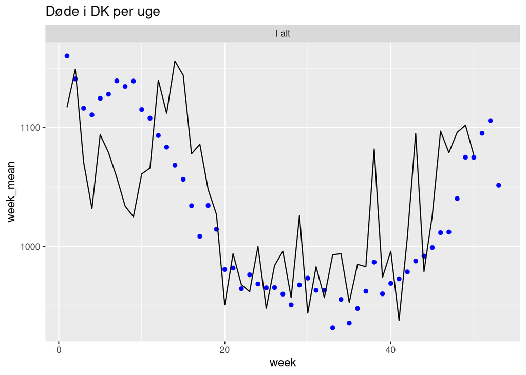

# Der dør flest 80-90 årige

Dødstallet topper for 80-90 årige. Det er også for de ældre, at årstidsvariationen er stærk.

Gennemsnit er blå prik, 2020 er sort streg. Der er ikke nogen tydelig overdødelighed i 2020.

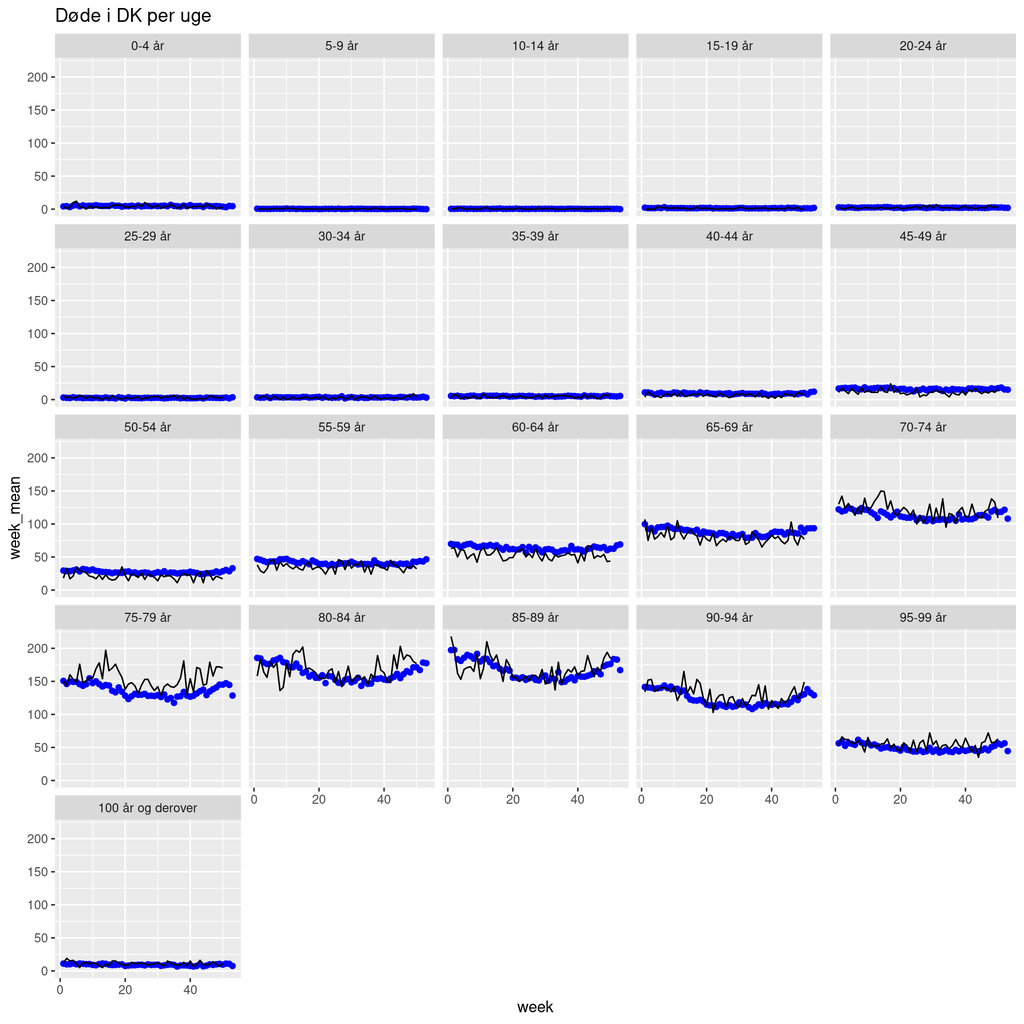

# I 2020 døde færre midaldrende og flere ældre

Op til 35 år er der ikke noget ved 2020 der stikker ud. Fra 35 - 70 år er der færre døde i 2020 end forventet. Over 70 år er der en overdødelighed efter ca uge 10 (nedlukningen kom i uge 11, 2020).

Bemærk at hvert plot har egen y-akse nedenfor. Blå prik er gennemsnit over 2007 til 2020. Sort streg er 2020 værdien.

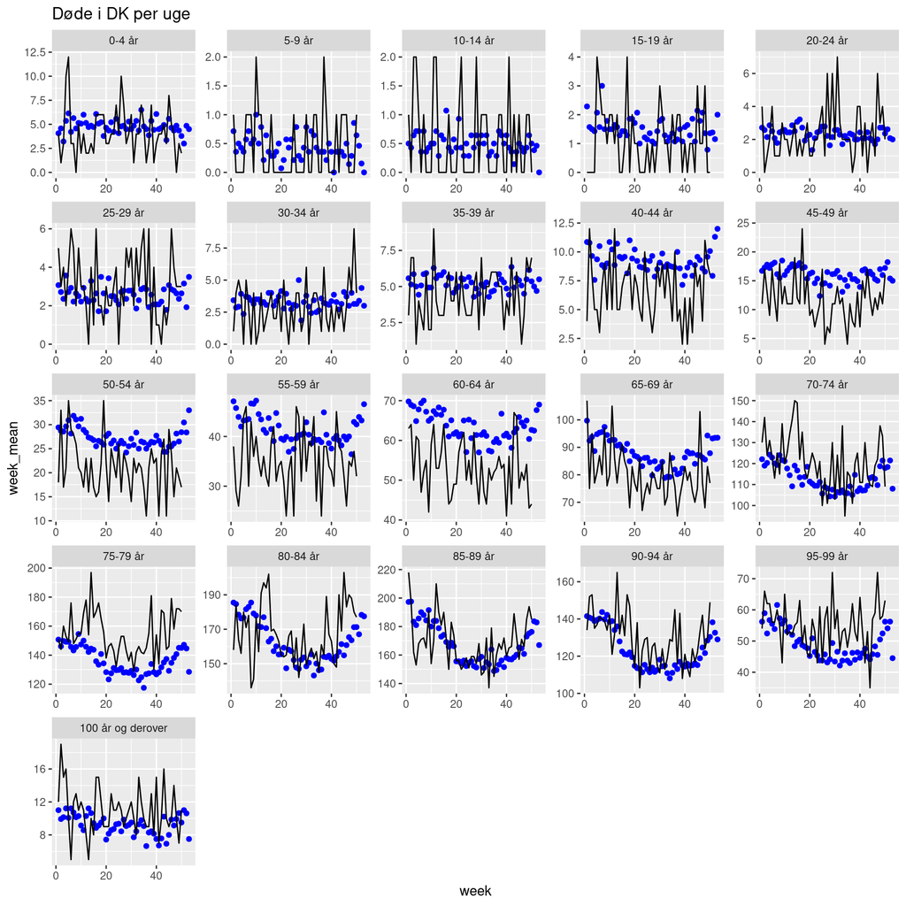

## Kønsfordeling

Mænds overdødelighed starter lidt før 20 års alderen og fortsætter frem til 80-85 år, hvor der dør lige mange mænd og kvinder. Det er også den aldersgruppe, hvor flest mænd dør (relativt til andre aldersgrupper). Kvinder dør typisk som 85-90 årige og derefter dør flere kvinder end mænd.

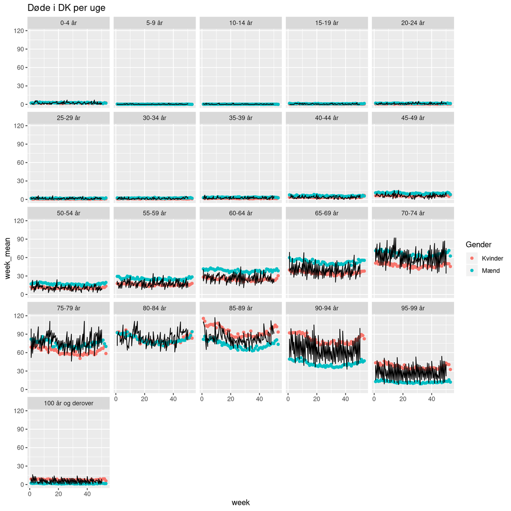

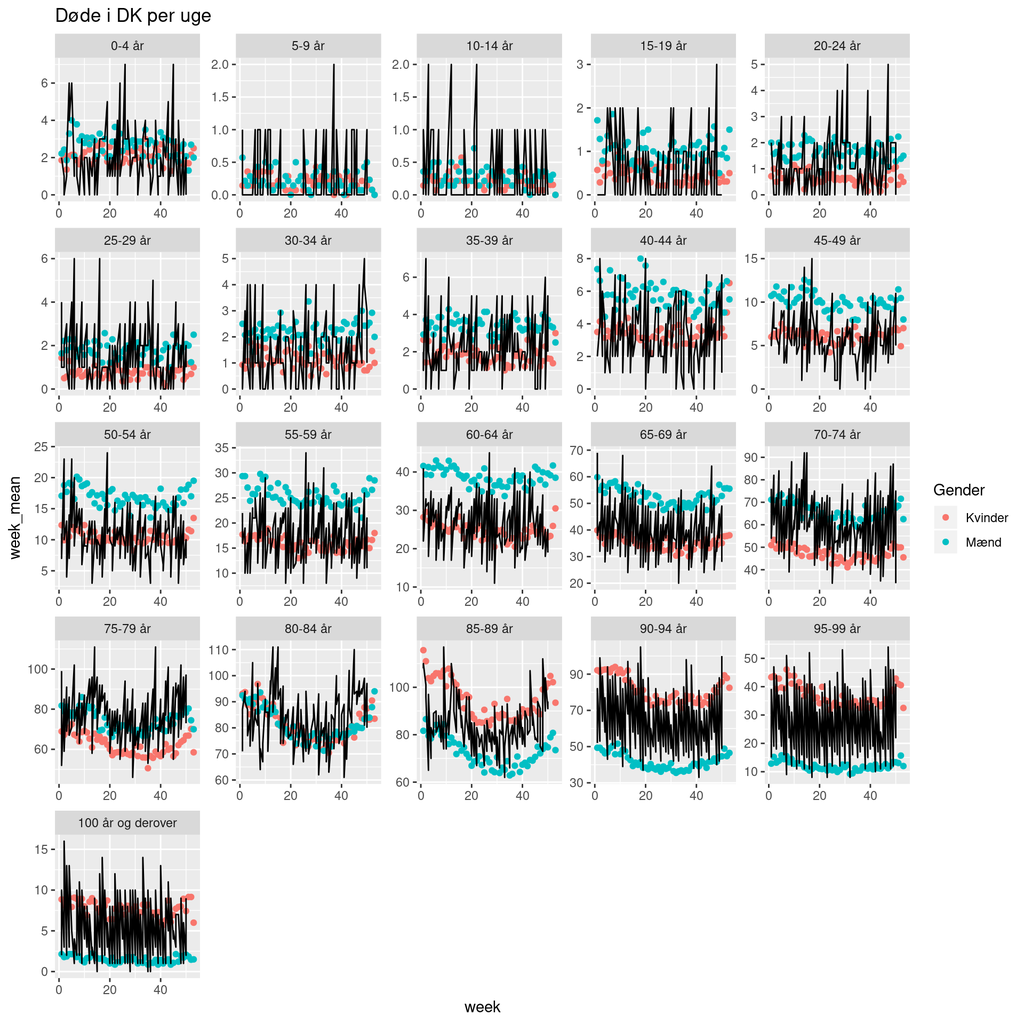

# Data

Antal døde i Danmark opgrjort per uge, køn og aldergruppe fra 2007 til 2020. Hentet fra Danmarks Statistik 2020-12-31: https://www.statistikbanken.dk/statbank5a/SelectVarVal/Define.asp?MainTable=DODC2&PLanguage=0&PXSId=0&wsid=cftree

Data kan også hentes splittet på region og i en opløsning på en dag.